# 10 Polynomials

Polynomials are a particular class of expressions that are simple enough to have many properties that can be analyzed. In particular, the key concepts of calculus: limits, continuity, derivatives, and integrals are all relatively trivial for polynomial functions. However, polynomials are flexible enough that they can be used to approximate a wide variety of functions. Indeed, though we don’t pursue this, we mention that `Julia`’s `ApproxFun` package exploits this to great advantage.

Here we discuss some vocabulary and basic facts related to polynomials and show how the add-on `SymPy` package can be used to model polynomial expressions within `SymPy`.

For our purposes, a *monomial* is simply a non-negative integer power of $x$ (or some other indeterminate symbol) possibly multiplied by a scalar constant. For example, $5x^4$ is a monomial, as are constants, such as $-2=-2x^0$ and the symbol itself, as $x = x^1$. In general, one may consider restrictions on where the constants can come from, and consider more than one symbol, but we won’t pursue this here, restricting ourselves to the case of a single variable and real coefficients.

A *polynomial* is a simply a sum or difference of monomials. After combining terms with same powers, a polynomial may be written uniquely as:
$$~
a_n x^n + a_{n-1}x^{n-1} + \cdots a_1 x + a_0, \quad a_n \neq 0
~$$

[figure not shown]

The numbers $a_0, a_1, \dots, a_n$ are the **coefficients** of the polynomial. With the convention that $x=x^1$ and $1 = x^0$, the monomials above have their power match their coefficient’s index, e.g., $a_ix^i$. Outside of the coefficient $a_n$, the other coefficients may be negative, positive or $0$. Except for the zero polynomial, the largest power $n$ is called the [degree](https://en.wikipedia.org/wiki/Degree_of_a_polynomial). The degree of the [zero](http://tinyurl.com/he6eg6s) polynomial is typically not defined, so as to make certain statements easier to say. The term $a_n$ is called the **leading coefficient**. When the leading coefficient is $1$, the polynomial is called a **monic polynomial**. The monomial $a_n x^n$ is the **leading term**. For example, the polynomial $-16x^2 - 32x + 100$ has degree $2$, leading coefficient $-16$ and leading term $-16x^2$. It is not monic, as the leading coefficient is not 1.

Lower degree polynomials have special names: a degree $0$ polynomial ($a_0$) is a non-zero constant, a degree 1 polynomial ($a_0+a_1x$) is called linear, a degree $2$ polynomial is quadratic, and degree $3$ cubic.

## 10.1 Linear polynomials

A special place is reserved for polynomials with degree 1. These are linear, as their graphs are straight lines. The general form
$$~
a_1 x + a_0
~$$

Is often written as $mx + b$, which is the **slope-intercept** form. The slope of a line determines how steeply it rises. The value of $m$ can be found from two points through the well-known formula:
$$~
m = \frac{y_1 - y_0}{x_1 - x_0} = \frac{\text{rise}}{\text{run}}
~$$

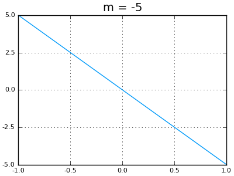

Graphs of y = mx for different values of m

The intercept, $b$, comes from the fact that when $x=0$ the expression is $b$. That is the graph of the function $f(x) = mx + b$ will have $(0,b)$ as a point on it.

More generally, we have the **point-slope** form of a line, written as a polynomial through
$$~
y_0 + m \cdot (x - x_0).
~$$

The slope is $m$ and the point $(x_0, y_0)$. Again, the line graphing this as a function of $x$ would have the point $(x_0,y_0)$ on it and have slope $m$. This form is more useful in calculus, as the information we have convenient is more likely to be related to a specific value of $x$, not the special value $x=0$.

Alternatively, we could think of the equation of a line in this form:
$$~
m \cdot(x - c)
~$$

Thinking in terms of transformations, this looks like the function $f(x) = x$ (whose graph is a line with slope 1) stretched in the $y$ direction by a factor of $m$ then shifted right by $c$ units. When $m>1$, this means the line grows faster. When $m< 0$, the line $f(x)=x$ is flipped through the $x$-axis so would head downwards, not upwards like $f(x) = x$.

## 10.2 Symbolic math in Julia

The indeterminate value `x` (or some other symbol) in a polynomial, is like a variable in a function and unlike a variable in `Julia`. Variables in `Julia` are identifiers, just a means to look up a specific, already determined, value. Rather, the symbol `x` is not yet determined, it is essentially a place holder for a future value. Although we have seen that `Julia` makes it very easy to work with mathematical functions, it is not the case that base `Julia` makes working with expressions of algebraic symbols easy. This makes sense, `Julia` is primarily designed for technical computing, where numeric approaches rule the day. However, symbolic math can be used from within `Julia` with an add-on package.

Symbolic math programs include well known ones like the commercial Mathematica and Maple. Mathematica powers the popular WolframAlpha website, which turns “natural” language into the specifics of a programming language. The open-source Sage project is an alternative to these two commercial giants. It includes a wide-range of open-source math projects available within its umbrella framework. (`Julia` can even be run from within the free service [cloud.sagemath.com](https://cloud.sagemath.com/projects).) A more focused project for symbolic math, is the SymPy Python library. SymPy is also used by Sage. However, SymPy provides a self-contained library that can be used standalone within a Python session. That is great for `Julia` users, as the `PyCall` package glues `Julia` to Python in a seamless manner. This allows the `Julia` package `SymPy` to provide functionality from SymPy within `Julia`.

`SymPy` is a `Julia` package, so is installed with the usual ease (`Pkg.add(“SymPy”)`). However, the package relies on both Python being installed and SymPy being added to the installed Python. This is done automatically on installation, if needed, when the `PyCall` package is installed.

To use `SymPy`, we create symbolic objects to be our indeterminate symbols. The `symbols` function does this and is used like:

```r
using SymPy
a,b,c = symbols("a,b,c")
x = symbols("x", real=true)
```

SymPy output issue for now…

The first use, shows that multiple symbols can be defined at once. The second shows the extra keyword argument `real=true`, which instructs `SymPy` to assume the `x` is real, as otherwise it assumes it is possibly complex. There are many other assumptions that can be made.

The *macro* `@syms` is like the second usage, only it does not need assignment, as the variable are created behind the scenes. This may be the easiest way to create symbolic values (no commas are used):

```r
@syms h t
```

The `SymPy` package does two basic things:

- It imports some of the functionality provided by `SymPy`.
- It overloads many `Julia` functions to work seamlessly with symbolic

expressions. This makes working with polynomials quite natural.

To illustrate, using the just defined `x`, here is how we can create the polynomial $-16x^2 + 100$:

```r
p = -16x^2 + 100
```

SymPy output issue for now…

That is, the expression is created just as you would create it within a function body. But here the result is still a symbolic object. We have assigned this expression to a variable `p`, and have not defined it as a function `p(x)`. Mentally keeping the distinction between expressions and functions is very important.

The `typeof` function shows that `p` is of a symbolic type (`Sym`):

```r
typeof(p)
```

```r
## SymPy.Sym
```

We can mix and match symbolic objects. This command creates an arbitrary quadratic polynomial:

```r
quad = a*x^2 + b*x + c
```

SymPy output issue for now…

Again, this is entered in a manner nearly identical to how we see such expressions typeset ($ax^2 + bx+c$), though we must remember to explicitly place the multiplication operator, as the symbols are not numeric literals.

We can apply many of `Julia`’s mathematical functions and the result will still be symbolic:

```r
sin(a*(x - b*pi) + c)
```

SymPy output issue for now…

Another example, might be the following combination:

```r
quad + quad^2 - quad^3
```

SymPy output issue for now…

## 10.3 Substitution: subs, replace

Algebraically working with symbolic expressions is straightforward. A different symbolic task is substitution. For example, replacing each instance of `x` in a polynomial, with, say, `(x-1)^2`. Substitution requires three things to be specified: an expression to work on, a variable to substitute, and a value to substitute in. The `subs` function is called as `subs(ex, variable, value)`. To do the task above for the polynomial $-16x^2 + 100$ we could have:

```r
p = -16x^2 + 100
subs(p, x, (x-1)^2)
```

SymPy output issue for now…

The value to substitute can depend on the variable, as illustrated; be a different variable; or be a numeric value, such as $2$:

```r
y = subs(p, x, 2)
```

SymPy output issue for now…

The result will always be of a symbolic type, even if the answer is just a number:

```r
typeof(y)
```

```r
## SymPy.Sym
```

There are two alternatives to `subs` that are a bit easier.

- First, one can pass in a “pair,” instead of three arguments:

```r
ex = -16x^2 + 100
subs(ex, x=>2)   # same as subs(ex, x, 2)
```

SymPy output issue for now…

Pairs are linked via `=>`. In this form the substitution happens from left to right, which means the right most values can depend on ones to the left.

- Even more compactly, when there is only one free variable, we can bypass the left side of the pair notation and “call” an expression like a function:

```r
ex(2)
```

SymPy output issue for now…

Though more than one variable can be substituted this way, if there is more than one free symbol in the expression, it is best to pass values as a pair indicating which variable is to be substituted for:

```r
quad = a*x^2 + b*x + c    # as before
quad(x => 2)
```

SymPy output issue for now…

##### 10.3.0.0.1 Example

Suppose we have the polynomial $p = ax^2 + bx +c$. What would it look like if we shifted right by $E$ units and up by $F$ units?

```r
a,b,c,E,F = symbols("a,b,c,E,F")
p = a*x^2 + b*x + c
p(x => x-E) + F
```

SymPy output issue for now…

And expanded this becomes:

```r
expand(p(x => x-E) + F)
```

SymPy output issue for now…

### 10.3.1 Conversion of symbolic numbers to Julia numbers

In the above, we substituted `2` in for `x` to get `y`:

```r
p = -16x^2 + 100
y = p(2)
```

SymPy output issue for now…

The value, $36$ is still symbolic, but clearly an integer. If we are just looking at the output, we can easily translate from the symbolic value to an integer, as they print similarly. However the conversion to an integer, or other type of number, does not happen automatically. If a number is needed to pass along to another `Julia` function, it must be converted. In general, conversions between different types are handled through various methods of `convert`. However, with `SymPy`, the `N` function will attempt to do the conversion for you:

```r
N(y)
```

```r
## 36
```

Conversion by `N` also works for other types of data, such as `Rational` and `Float64`. For getting more digits of accuracy, a precision can be passed to `N`. The following command will take the symbolic value for $\pi$, `PI`, and produce about 60 digits worth as a `BigFloat` value:

```r
N(PI, 60)
```

```r
## 3.141592653589793238462643383279502884197169399375105820974939
```

Conversion will fail if the value to be converted contains free symbols, as would be expected.

## 10.4 Graphical properties of polynomials

Consider the graph of the polynomial `x^5 - x + 1`:

```r
using Plots
plot(x^5 - x + 1, -3/2, 3/2)
```

[output not shown]

(Plotting symbolic expressions is similar to plotting a function, in that the expression is passed in as the first argument. The expression must have only one free variable, as above, or an error will occur.)

- there may be values for `x` where the graph crosses the $x$ axis (real roots of the polynomial);
- there may be peaks and valleys (local maxima and local minima)
- except for constant polynomials, the ultimate behaviour for large values of $\lvert x\rvert$ is either both sides of the graph going to positive infinity, or negative infinity, or as in this graph one to the positive infinity and one to negative infinity. In particular, there is no *horizontal asymptote*.

To investigate this last point, let’s consider the case of the monomial $x^n$. When $n$ is even, the following animations shows that larger values of $n$ have greater growth once outside of $[-1,1]$:

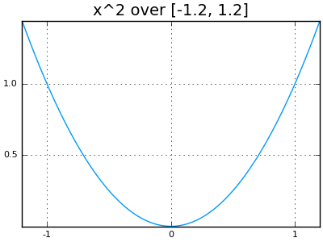

Demonstration that x^10 grows faster than x^8, … and x^2 grows faster than x^0 (which is constant).

Of course, this is expected, as, for example, $2^2 < 2^4 < 2^6 < \cdots$. The general shape of these terms is similar – $U$ shaped, and larger powers dominate the smaller powers as $\lvert x\rvert$ gets big.

```r
plot(x^5, -2, 2)
```

[output not shown]

Again, for larger powers the shape is similar, but the growth is faster.

### 10.4.1 Leading term dominates

To see the roots and/or the peaks and valleys of a polynomial requires a judicious choice of viewing window, as ultimately the leading term will dominate the graph. The following animation of $(x-5)(x-3)(x-2)(x-1)$ illustrates. Subsequent images show a widening of the plot window until the graph appears U-shaped.

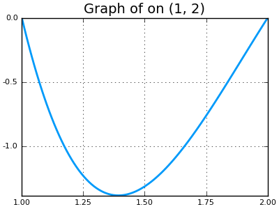

Ulitmately the leading term ($x^4$ here) dominates the graph

The leading term in the animation is $x^4$, so the graphic is U-shaped, were it an odd power, then the left and right sides would each head off to different signs of infinity.

To illustrate analytically why the leading term dominates, consider the polynomial $2x^5 - x + 1$ and then factor out the largest power, $x^5$, leaving a product:
$$~
x^5 \cdot (2 - \frac{1}{x^4} + \frac{1}{x^5}).
~$$

For large $\lvert x\rvert$, the last two terms in the product on the right get close to $0$, so this expression is *basically* just $2x^5$ – the leading term.

##### 10.4.1.0.1 Example

Suppose $p = a_n x^n + \cdots + a_1 x + a_0$ with $a_n > 0$. Then by the above, evenually for large $x > 0$ we have $p > 0$, as that is the behaviour of $a_n x^n$. Were $a_n < 0$, then eventually for large $x>0$, $p < 0$.

Now consider the related polynomial, $q$, where we multiply $p$ by $x^n$ and substitute in $1/x$ for $x$. This is the “reversed” polynomial, as we see in this illustration for $n=2$:

```r
p = a*x^2 + b*x + c
n = 2    # the degree of p
q = x^n * p(x => 1/x)
```

SymPy output issue for now…

That is, if $p$ has $a_n > 0$ but $a_0 < 0$ then the graph of $p$ must cross the $x$ axis.

This observation is the start of Descartes’ rule of [signs](http://sepwww.stanford.edu/oldsep/stew/descartes.pdf), which counts the change of signs of the coefficients in `p` to say something about how many possible crossing there are of the $x$ axis by the graph of the polynomial $p$.